# Lab 9 assignment

Lucas Parvin

3-28-2024

### **Load Packages**

```r
rm(list=ls())

require(tidyterra)
require(dismo)
require(tidyverse)
require(terra)
require(predicts)
require(ggnewscale)
require(mgcv)
require(randomForest)
require(maxnet)
require(enmSdmX)
require(gbm)
require(PresenceAbsence)
require(ecospat)
```

# This first code chunk just recreates the maps we built in the lab.

```r
# Model building data
vathData = read.csv('https://raw.githubusercontent.com/ValenteJJ/SpatialEcology/main/Week8/vath_2004.csv')

vathPres = vathData %>% filter(VATH==1)
vathAbs = vathData %>% filter(VATH==0)

vathPresXy = as.matrix(vathPres %>% select(EASTING, NORTHING))
vathAbsXy = as.matrix(vathAbs %>% select(EASTING, NORTHING))



# Validation data
vathVal = read.csv('https://raw.githubusercontent.com/ValenteJJ/SpatialEcology/main/Week8/vath_VALIDATION.csv')

vathValPres = vathVal %>% filter(VATH==1)
vathValAbs = vathVal %>% filter(VATH==0)

vathValXy = as.matrix(vathVal %>% select(EASTING, NORTHING))
vathValPresXy = as.matrix(vathValPres %>% select(EASTING, NORTHING))
vathValAbsXy = as.matrix(vathValAbs %>% select(EASTING, NORTHING))



# Bringing in the covariates
elev = rast('https://github.com/ValenteJJ/SpatialEcology/raw/main/Week8/elevation.tif')
canopy = rast('https://github.com/ValenteJJ/SpatialEcology/raw/main/Week8/canopy.tif')
mesic = rast('https://github.com/ValenteJJ/SpatialEcology/raw/main/Week8/mesic.tif')
precip = rast('https://github.com/ValenteJJ/SpatialEcology/raw/main/Week8/precip.tif')


# Resampling to make the covariate rasters match
mesic = resample(x = mesic, y = elev, 'near')
precip = resample(x = precip, y = elev, 'bilinear')

mesic = mask(mesic, elev)
precip = mask(precip, elev)

# Mesic forest within 1 km
probMatrix = focalMat(mesic, 1000, type='circle', fillNA=FALSE)
mesic1km = focal(mesic, probMatrix, fun='sum')


# Building the raster stack
layers = c(canopy, elev, mesic1km, precip)
names(layers) = c('canopy', 'elev', 'mesic1km', 'precip')


#Creating background points
set.seed(23)

backXy = data.frame(backgroundSample(layers, n=2000, p=vathPresXy))

# Extracting covariates for our different points
presCovs = terra::extract(layers, vathPresXy)
absCovs = terra::extract(layers, vathAbsXy)
backCovs = terra::extract(layers, backXy)
valCovs = terra::extract(layers, vathValXy)

presCovs = data.frame(vathPresXy, presCovs, pres=1)
absCovs = data.frame(vathAbsXy, absCovs, pres=0)
backCovs = data.frame(backXy, backCovs, pres=0)
valCovs = data.frame(vathValXy, valCovs)

presCovs = presCovs[complete.cases(presCovs),]
absCovs = absCovs[complete.cases(absCovs),]
backCovs = backCovs[complete.cases(backCovs),]

# Combining presence and background data into one dataframe

backCovs = backCovs %>% select(-ID)
colnames(presCovs)[1:2] = c('x', 'y')
colnames(absCovs)[1:2] = c('x', 'y')

presBackCovs = rbind(presCovs, backCovs)
presAbsCovs = rbind(presCovs, absCovs)

#valCovs = valCovs %>% mutate(VATH = vathVal$VATH) # Delete?
#valCovs = valCovs[complete.cases(valCovs),] # Delete?


# Fitting bioclim envelope model
tmp = presCovs %>% select(elev, precip, mesic1km, canopy) %>%
  as.matrix()

bioclim = envelope(tmp)

bioclimMap = predict(layers, bioclim)



# Fitting GLM
glmModel = glm(pres ~ canopy + elev + I(elev^2) + mesic1km + precip, family='binomial', data=presBackCovs)

glmMap = predict(layers, glmModel, type='response')


# Fitting GAM
gamModel = gam(pres ~ s(canopy, k=6) + s(elev, k=6) + s(mesic1km, k=6) + s(precip, k=6), family='binomial', data=presBackCovs, method='ML')

gamMap = predict(layers, gamModel, type='response')


# Fitting boosted regression tree model

boostModel = gbm(pres ~ elev + canopy + mesic1km + precip, distribution='bernoulli', n.trees=100, interaction.depth=2, shrinkage=0.1, bag.fraction=0.5, data=presBackCovs)

boostMap = predict(layers, boostModel, type='response')
boostMap = mask(boostMap, layers$canopy)


# Fitting random forest model

rfModel = randomForest(as.factor(pres) ~ canopy + elev + mesic1km + precip, data=presBackCovs, mtry=2, ntree=500, na.action = na.omit)

rfMap = predict(layers, rfModel, type='prob', index=2)


#Fitting maxent model

pbVect = presBackCovs$pres
covs = presBackCovs %>% select(canopy:precip)

maxentModel = maxnet(p = pbVect,
                     data= covs,
                     regmult = 1,
                     classes='lqpht')


maxentMap = predictMaxNet(maxentModel, layers, type='logistic')
```

# Challenge 1 (4 points)

In the lab, we fit 6 SDMs. We then calculated discrimination statistics for all 6 and a calibration plot for 1 of them. Create calibration plots for the remaining 5 models, and then make a decision (based on your suite of discrimination statistics and calibration plots) about which of your SDMs is “best.” Defend your answer.

```r
# Set-up

tmp = valCovs %>% mutate(VATH = vathVal$VATH)
tmp = tmp[complete.cases(tmp),]


valData = data.frame('ID' = 1:nrow(tmp)) %>%
  mutate(obs = tmp$VATH,
         bioVal = predict(bioclim, tmp %>% select(canopy:precip)),
         glmVal = predict(glmModel, tmp %>% select(canopy:precip), type='response'),
         gamVal = predict(gamModel, tmp %>% select(canopy:precip), type='response'),
         boostVal = predict(boostModel, tmp %>% select(canopy:precip), type='response'),
         rfVal = predict(rfModel, tmp %>% select(canopy:precip), type='prob')[,2],
         maxentVal = predict(maxentModel, tmp %>% select(canopy:precip), type='logistic')[,1])


summaryEval = data.frame(matrix(nrow=0, ncol=9))

nModels = ncol(valData)-2


for(i in 1:nModels){

  #AUC
  auc = auc(valData, which.model = i)

  #Find threshold to maximize Kappa
  kappaOpt = optimal.thresholds(valData, which.model = i, opt.methods=3)

  #Sensitivity
  sens = sensitivity(cmx(valData, which.model=i, threshold = kappaOpt[[2]]))

  #Specificity
  spec = specificity(cmx(valData, which.model = i, threshold = kappaOpt[[2]]))

  #True skill statistic
  tss = sens$sensitivity + spec$specificity - 1

  #Kappa
  kappa = Kappa(cmx(valData, which.model = i, threshold = kappaOpt[[2]]))

  #Correlation between predicted and realized values
  corr = cor.test(valData[,2], valData[,i+2])$estimate

  #Log likelihood
  ll = sum(log(valData[,i+2]*valData[,2] + (1-valData[,i+2]) * (1-valData[,2])))
  ll = ifelse(ll == '-Inf', sum(log(valData[,i+2] + 0.01)*valData[,2] + log((1-valData[,i+2]))*(1-valData[,2])), ll)

  #Put them all together and save the values
  summaryI = c(i, auc$AUC, corr, ll, kappaOpt[[2]], sens$sensitivity, spec$specificity, tss, kappa[[1]])
  summaryEval = rbind(summaryEval, summaryI)
}
```

### **Summary Test Statistics**

```r
summaryEval = summaryEval %>%
  setNames(c('model', 'auc', 'corr', 'll', 'threshold', 'sens', 'spec', 'tss', 'kappa')) %>%
  mutate(model = colnames(valData)[3:8])

summaryEval
```

| model | auc | corr | ll | threshold | sens | spec | tss | kappa |
| --- | --- | --- | --- | --- | --- | --- | --- | --- |
| bioVal | 0.5830024 | 0.06185483 | -639.2494 | 0.09 | 0.5838926 | 0.5471698 | 0.1310624 | 0.04043921 |
| glmVal | 0.6726221 | 0.17124018 | -520.3501 | 0.09 | 0.5033557 | 0.7707261 | 0.2740818 | 0.13677875 |
| gamVal | 0.6455923 | 0.14414314 | -542.8045 | 0.08 | 0.5906040 | 0.6569468 | 0.2475509 | 0.09325225 |
| boostVal | 0.6403391 | 0.12477095 | -540.9090 | 0.04 | 0.6308725 | 0.5717553 | 0.2026278 | 0.06472780 |
| rfVal | 0.6322577 | 0.12475181 | -598.7629 | 0.09 | 0.4765101 | 0.7106918 | 0.1872019 | 0.08090368 |
| maxentVal | 0.6598862 | 0.15539050 | -996.9272 | 0.54 | 0.4563758 | 0.7993139 | 0.2556897 | 0.13980877 |

### **Calibration Plots**

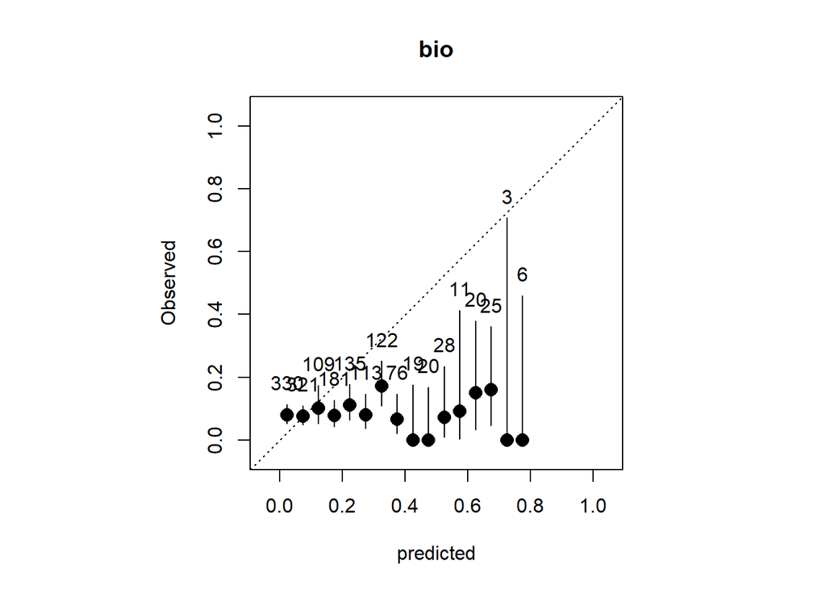

|  | BinCenter | NBin | BinObs | BinPred | BinObsCIlower | BinObsCIupper |
| --- | --- | --- | --- | --- | --- | --- |
| 1 | 0.025 | 330 | 0.07878788 | 0.02740032 | 0.052110596 | 0.1133123 |
| 2 | 0.075 | 321 | 0.07476636 | 0.08060338 | 0.048489220 | 0.1092054 |
| 3 | 0.125 | 109 | 0.10091743 | 0.12351521 | 0.051463722 | 0.1733973 |
| 4 | 0.175 | 181 | 0.07734807 | 0.17987787 | 0.042930966 | 0.1263720 |
| 5 | 0.225 | 135 | 0.11111111 | 0.22479532 | 0.063537703 | 0.1766329 |
| 6 | 0.275 | 113 | 0.07964602 | 0.26483465 | 0.037066265 | 0.1458126 |
| 7 | 0.325 | 122 | 0.17213115 | 0.33132010 | 0.109824388 | 0.2510049 |
| 8 | 0.375 | 76 | 0.06578947 | 0.37548476 | 0.021705078 | 0.1468904 |
| 9 | 0.425 | 19 | 0.00000000 | 0.42603878 | 0.000000000 | 0.1764669 |
| 10 | 0.475 | 20 | 0.00000000 | 0.47789474 | 0.000000000 | 0.1684335 |

[output cut: 10 more lines]

```r
# Calibration
calibration.plot(valData, which.model = 1, N.bins = 20, xlab='predicted', ylab='Observed', main='bio')
```

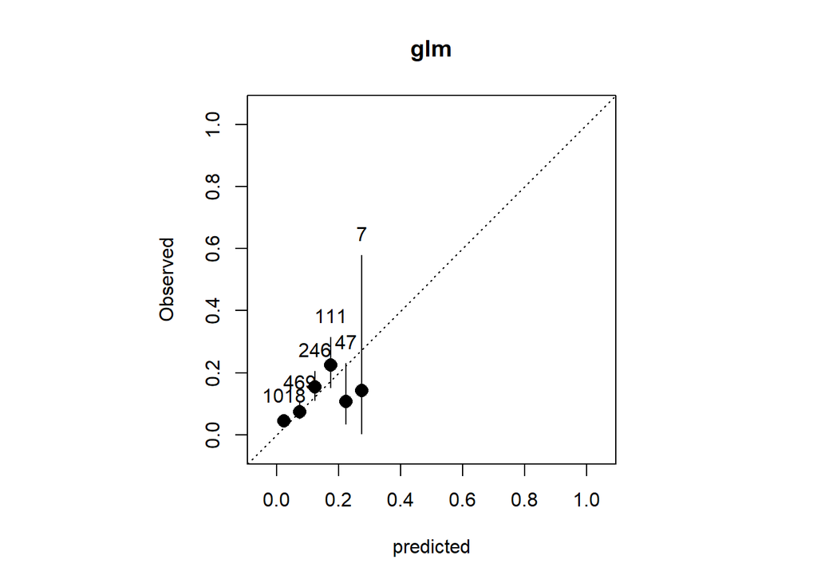

|  | BinCenter | NBin | BinObs | BinPred | BinObsCIlower | BinObsCIupper |
| --- | --- | --- | --- | --- | --- | --- |
| 1 | 0.025 | 1018 | 0.04420432 | 0.02102475 | 0.032422672 | 0.05870435 |
| 2 | 0.075 | 469 | 0.07462687 | 0.07025664 | 0.052528061 | 0.10226185 |
| 3 | 0.125 | 246 | 0.15447154 | 0.12028217 | 0.111690732 | 0.20580371 |
| 4 | 0.175 | 111 | 0.22522523 | 0.17153899 | 0.151368389 | 0.31426942 |
| 5 | 0.225 | 47 | 0.10638298 | 0.21755361 | 0.035456301 | 0.23104763 |
| 6 | 0.275 | 7 | 0.14285714 | 0.27078331 | 0.003610297 | 0.57872320 |
| 7 | 0.325 | 0 | NA | NA | NA | NA |
| 8 | 0.375 | 0 | NA | NA | NA | NA |
| 9 | 0.425 | 0 | NA | NA | NA | NA |
| 10 | 0.475 | 0 | NA | NA | NA | NA |

[output cut: 10 more lines]

```r
calibration.plot(valData, which.model = 2, N.bins = 20, xlab='predicted', ylab='Observed', main='glm')
```

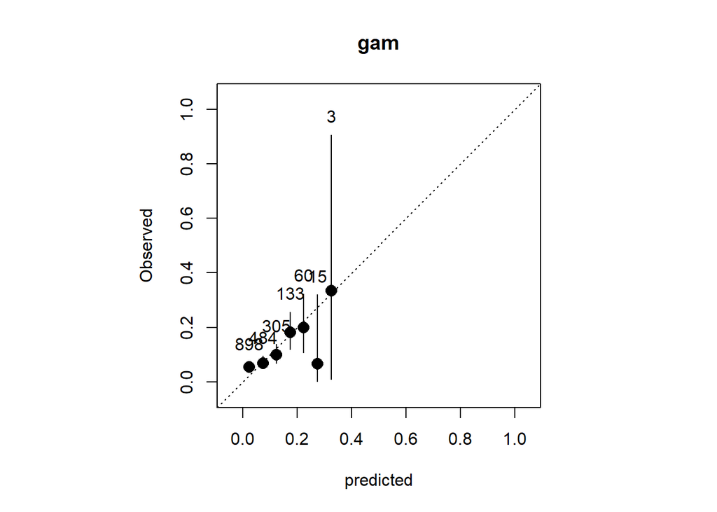

|  | BinCenter | NBin | BinObs | BinPred | BinObsCIlower | BinObsCIupper |
| --- | --- | --- | --- | --- | --- | --- |
| 1 | 0.025 | 898 | 0.05345212 | 0.01745286 | 0.039670863 | 0.07024810 |
| 2 | 0.075 | 484 | 0.06818182 | 0.07269015 | 0.047394627 | 0.09442294 |
| 3 | 0.125 | 305 | 0.09836066 | 0.11937688 | 0.067351767 | 0.13743382 |
| 4 | 0.175 | 133 | 0.18045113 | 0.17068971 | 0.119173980 | 0.25649344 |
| 5 | 0.225 | 60 | 0.20000000 | 0.21736678 | 0.107841123 | 0.32330042 |
| 6 | 0.275 | 15 | 0.06666667 | 0.26714133 | 0.001686430 | 0.31948457 |
| 7 | 0.325 | 3 | 0.33333333 | 0.30356140 | 0.008403759 | 0.90570068 |
| 8 | 0.375 | 0 | NA | NA | NA | NA |
| 9 | 0.425 | 0 | NA | NA | NA | NA |
| 10 | 0.475 | 0 | NA | NA | NA | NA |

[output cut: 10 more lines]

```r
calibration.plot(valData, which.model = 3, N.bins = 20, xlab='predicted', ylab='Observed', main='gam')
```

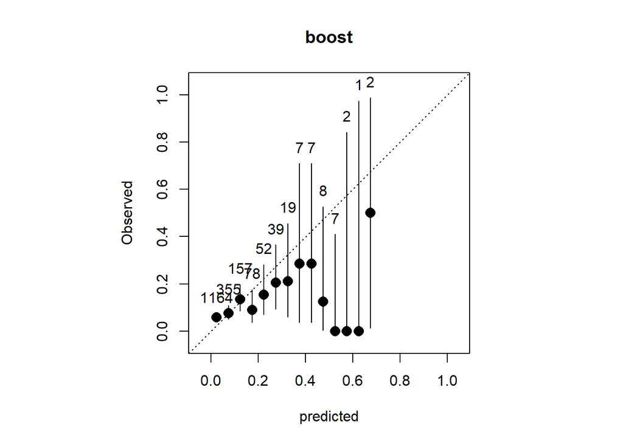

|  | BinCenter | NBin | BinObs | BinPred | BinObsCIlower | BinObsCIupper |
| --- | --- | --- | --- | --- | --- | --- |
| 1 | 0.025 | 1164 | 0.05841924 | 0.02152359 | 0.045646904 | 0.07347582 |
| 2 | 0.075 | 355 | 0.07605634 | 0.07068677 | 0.050717552 | 0.10873039 |
| 3 | 0.125 | 157 | 0.13375796 | 0.12333975 | 0.084743099 | 0.19716955 |
| 4 | 0.175 | 78 | 0.08974359 | 0.17211087 | 0.036846896 | 0.17620347 |
| 5 | 0.225 | 52 | 0.15384615 | 0.22220916 | 0.068839234 | 0.28081108 |
| 6 | 0.275 | 39 | 0.20512821 | 0.27162186 | 0.092963927 | 0.36464424 |
| 7 | 0.325 | 19 | 0.21052632 | 0.32689095 | 0.060524538 | 0.45565308 |
| 8 | 0.375 | 7 | 0.28571429 | 0.37853025 | 0.036692566 | 0.70957914 |
| 9 | 0.425 | 7 | 0.28571429 | 0.42630137 | 0.036692566 | 0.70957914 |
| 10 | 0.475 | 8 | 0.12500000 | 0.46620678 | 0.003159724 | 0.52650967 |

[output cut: 10 more lines]

```r
calibration.plot(valData, which.model = 4, N.bins = 20, xlab='predicted', ylab='Observed', main='boost')
```

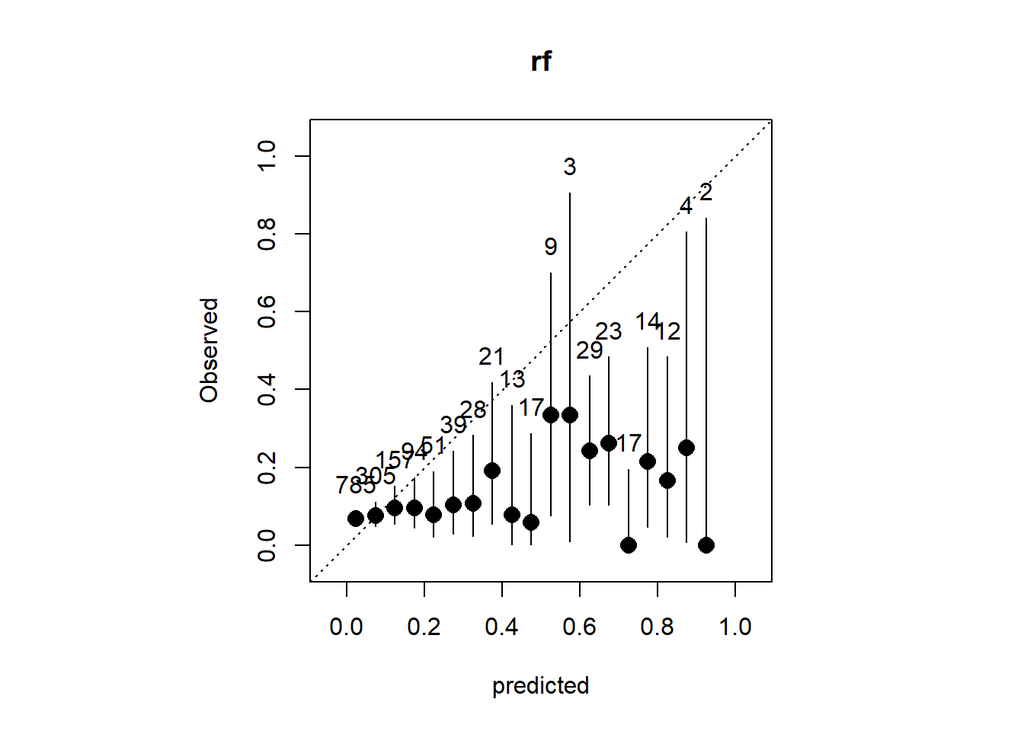

|  | BinCenter | NBin | BinObs | BinPred | BinObsCIlower | BinObsCIupper |
| --- | --- | --- | --- | --- | --- | --- |
| 1 | 0.025 | 785 | 0.06878981 | 0.02089936 | 0.052096062 | 0.08880555 |
| 2 | 0.075 | 305 | 0.07540984 | 0.07438689 | 0.048401650 | 0.11100464 |
| 3 | 0.125 | 157 | 0.09554140 | 0.12533758 | 0.054465292 | 0.15268263 |
| 4 | 0.175 | 94 | 0.09574468 | 0.17397872 | 0.044722075 | 0.17398569 |
| 5 | 0.225 | 51 | 0.07843137 | 0.22117647 | 0.021783562 | 0.18880601 |
| 6 | 0.275 | 39 | 0.10256410 | 0.27805128 | 0.028660105 | 0.24220973 |
| 7 | 0.325 | 28 | 0.10714286 | 0.32285714 | 0.022665091 | 0.28226440 |
| 8 | 0.375 | 21 | 0.19047619 | 0.37847619 | 0.054463568 | 0.41906604 |
| 9 | 0.425 | 13 | 0.07692308 | 0.41830769 | 0.001945628 | 0.36029744 |
| 10 | 0.475 | 17 | 0.05882353 | 0.47411765 | 0.001488174 | 0.28688940 |

[output cut: 10 more lines]

```r
calibration.plot(valData, which.model = 5, N.bins = 20, xlab='predicted', ylab='Observed', main='rf')
```

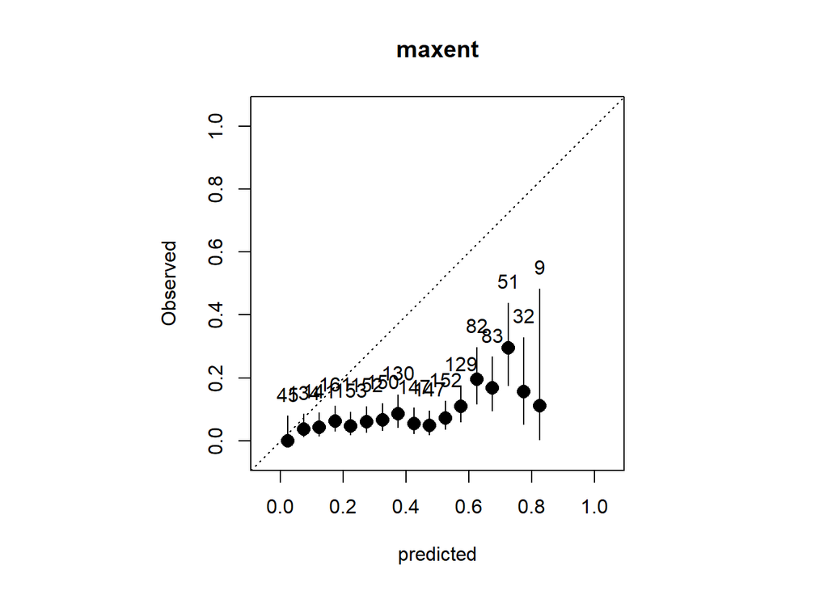

|  | BinCenter | NBin | BinObs | BinPred | BinObsCIlower | BinObsCIupper |
| --- | --- | --- | --- | --- | --- | --- |
| 1 | 0.025 | 45 | 0.00000000 | 0.03737375 | 0.000000000 | 0.07870510 |
| 2 | 0.075 | 134 | 0.03731343 | 0.07499284 | 0.012224700 | 0.08492800 |
| 3 | 0.125 | 141 | 0.04255319 | 0.12623180 | 0.015774009 | 0.09031787 |
| 4 | 0.175 | 161 | 0.06211180 | 0.17361489 | 0.030183960 | 0.11125799 |
| 5 | 0.225 | 153 | 0.04575163 | 0.22640792 | 0.018589715 | 0.09199214 |
| 6 | 0.275 | 152 | 0.05921053 | 0.27410461 | 0.027429342 | 0.10942263 |
| 7 | 0.325 | 150 | 0.06666667 | 0.32422157 | 0.032429728 | 0.11918398 |
| 8 | 0.375 | 130 | 0.08461538 | 0.37375507 | 0.042997994 | 0.14635655 |
| 9 | 0.425 | 147 | 0.05442177 | 0.42439990 | 0.023785326 | 0.10441525 |
| 10 | 0.475 | 147 | 0.04761905 | 0.47338194 | 0.019356938 | 0.09565089 |

[output cut: 10 more lines]

```r
calibration.plot(valData, which.model = 6, N.bins = 20, xlab='predicted', ylab='Observed', main='maxent')
```

# Challenge 2 (4 points)

Each SDM we created uses a different algorithm with different assumptions. Because of this, ecologists frequently use “ensemble” approaches that aggregate predictions from multiple models in some way. Here we are going to create an ensemble model by calculating a weighted average of the predicted occupancy values at each pixel. We will calculate weights based on model AUC values to ensure that the models with the best AUC values have the most influence on the predicted values in the ensemble model.

Create a raster stack that combines the glmMap, gamMap, boostMap, and rfMap (hint use c()).

```r
modelStack <- c(glmMap, gamMap, boostMap, rfMap)
```

Next, create a vector of the AUC values for each model.

```r
aucVector <- summaryEval$auc
```

Lastly, use the weighted.mean() function in the terra package to create the new raster as a weighted average of the previous 4 rasters.

```r
weighted_raster <- weighted.mean(modelStack, aucVector)
```

Plot the result, and explain why we left out the bioclim and Maxent models for this ensemble model.

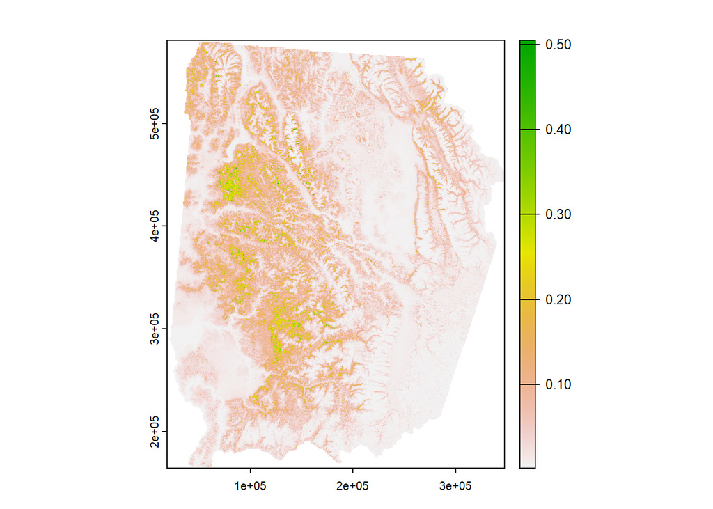

```r
# Improve later
plot(weighted_raster)
```

**ANSWER:** The the bioclim and Maxent models were left out because these models operate under different assumptions than GLM, GAM, Boosted Regression Trees, and Random Forest models. Bioclim uses an envelope approach, considering environmental minimums, maximums, and using presence data. Maxent, also niche-based, focuses on the probability of species’ presence with respect to different environmental variables and might scale differently from the predictions of regression or machine learning models. The ensemble model aims to combine models with similar output scales and interpretations, ensuring that the weighted average is meaningful and consistent across the landscape. Thus, combining models that scale differently or represent slightly different things would make the ensemble model difficult to interpret.

# Challenge 3 (4 points)

Is this ensemble model an improvement over one of the models you built previously? Provide evidence and explain the criteria you used to come to your conclusion.

```r
ensemble_preds <- terra::extract(weighted_raster, as.matrix(valCovs %>% select(EASTING, NORTHING)))

# Add these predictions to `valData`
valData$ensembleVal <- ensemble_preds[(1:1898),]

# Confined to 6 columns, so I omitted bioclim model
summaryEval = summaryEval %>%
  setNames(c('model', 'auc', 'corr', 'll', 'threshold', 'sens', 'spec', 'tss', 'kappa')) %>%
  mutate(model = colnames(valData)[4:9])

summaryEval
```

| model | auc | corr | ll | threshold | sens | spec | tss | kappa |
| --- | --- | --- | --- | --- | --- | --- | --- | --- |
| glmVal | 0.5830024 | 0.06185483 | -639.2494 | 0.09 | 0.5838926 | 0.5471698 | 0.1310624 | 0.04043921 |
| gamVal | 0.6726221 | 0.17124018 | -520.3501 | 0.09 | 0.5033557 | 0.7707261 | 0.2740818 | 0.13677875 |
| boostVal | 0.6455923 | 0.14414314 | -542.8045 | 0.08 | 0.5906040 | 0.6569468 | 0.2475509 | 0.09325225 |
| rfVal | 0.6403391 | 0.12477095 | -540.9090 | 0.04 | 0.6308725 | 0.5717553 | 0.2026278 | 0.06472780 |
| maxentVal | 0.6322577 | 0.12475181 | -598.7629 | 0.09 | 0.4765101 | 0.7106918 | 0.1872019 | 0.08090368 |
| ensembleVal | 0.6598862 | 0.15539050 | -996.9272 | 0.54 | 0.4563758 | 0.7993139 | 0.2556897 | 0.13980877 |

# Challenge 4 (4 points)

In the lab we built models using presence-background data then validated those models with presence-absence data. For this challenge, you’re going to compare the predictive ability of a model built using presence-background data with one built using presence-absence data.

Fit a GLM using the presence-background data as we did in the lab (i.e., use the presBackCovs dataframe). Fit a second GLM using the presence-absence data (i.e., use the presAbsCovs dataframe). Validate both of these models on the novel presence-absence data (valCovs dataset). Specifically, calculate and compare AUC, Kappa, and TSS for these two models. Which model does a better job of prediction for the validation data and why do you think that is?

```r
glmModelBack = glm(pres ~ canopy + elev + I(elev^2) + mesic1km + precip, family='binomial', data=presBackCovs)
glmModelAbs = glm(pres ~ canopy + elev + I(elev^2) + mesic1km + precip, family = 'binomial', data=presAbsCovs)

glmBackMap = predict(layers, glmModel, type='response')
glmAbsMap = predict(layers, glmModel, type='response')

tmp = valCovs %>% mutate(VATH = vathVal$VATH)
tmp = tmp[complete.cases(tmp),]

valData = data.frame('ID' = 1:nrow(tmp)) %>%
  mutate(obs = tmp$VATH,
         glmBackVal = predict(glmModelBack, tmp %>% select(canopy:precip), type='response'), # Updated line
         glmAbsVal = predict(glmModelAbs, tmp %>% select(canopy:precip), type='response'), # Updated line
         )

summaryEval = data.frame(matrix(nrow=0, ncol=9))

nModels = ncol(valData)-2


for(i in 1:nModels){

  #AUC
  auc = auc(valData, which.model = i)

  #Find threshold to maximize Kappa
  kappaOpt = optimal.thresholds(valData, which.model = i, opt.methods=3)

  #Sensitivity
  sens = sensitivity(cmx(valData, which.model=i, threshold = kappaOpt[[2]]))

  #Specificity
  spec = specificity(cmx(valData, which.model = i, threshold = kappaOpt[[2]]))

  #True skill statistic
  tss = sens$sensitivity + spec$specificity - 1

  #Kappa
  kappa = Kappa(cmx(valData, which.model = i, threshold = kappaOpt[[2]]))

  #Correlation between predicted and realized values
  corr = cor.test(valData[,2], valData[,i+2])$estimate

  #Log likelihood
  ll = sum(log(valData[,i+2]*valData[,2] + (1-valData[,i+2]) * (1-valData[,2])))
  ll = ifelse(ll == '-Inf', sum(log(valData[,i+2] + 0.01)*valData[,2] + log((1-valData[,i+2]))*(1-valData[,2])), ll)

  #Put them all together and save the values
  summaryI = c(i, auc$AUC, corr, ll, kappaOpt[[2]], sens$sensitivity, spec$specificity, tss, kappa[[1]])
  summaryEval = rbind(summaryEval, summaryI)
}


summaryEval = summaryEval %>%
  setNames(c('model', 'auc', 'corr', 'll', 'threshold', 'sens', 'spec', 'tss', 'kappa')) %>%
  mutate(model = colnames(valData)[3:4])

summaryEval
```

| model | auc | corr | ll | threshold | sens | spec | tss | kappa |
| --- | --- | --- | --- | --- | --- | --- | --- | --- |
| glmBackVal | 0.6726221 | 0.1712402 | -520.3501 | 0.09 | 0.5033557 | 0.7707261 | 0.2740818 | 0.1367787 |
| glmAbsVal | 0.7240648 | 0.2156114 | -525.9662 | 0.08 | 0.8187919 | 0.5122927 | 0.3310847 | 0.0936411 |

**ANSWER:** The AUC value indicates that the presence-absence model is better. The TSS also indicates that the presence-absence model is better. In contrast, the Kappa statistic indicates that the presence-background model has higher agreement than the presence-absence model. Ultimately, while neither model appears to be very good, the presence-absence model seems to be stronger, indicated by 2 of the 3 statistics focused on in this challenge. Furthermore, intuitively, I would guess that a model fit with true absences would make for a better model, if the absences are not severely biased.

# Challenge 5 (4 points)

Now calculate the same statistics (AUC, Kappa, and TSS) for each model you developed in Challenge 4 using K-fold validation with 5 groups. Do these models perform better or worse based on K-fold validation (as compared to validation based on novel data)? Why might that occur?

```r
#glmModelBack = glm(pres ~ canopy + elev + I(elev^2) + mesic1km + precip, family='binomial', data=presBackCovs)
#glmModelAbs = glm(pres ~ canopy + elev + I(elev^2) + mesic1km + precip, family = 'binomial', data=presAbsCovs)
#glmBackMap = predict(layers, glmModel, type='response')
#glmAbsMap = predict(layers, glmModel, type='response')
#set.seed(23)

#nFolds = 5
#kfoldPres = kfold(presCovs, k=nFolds) # for both models
#kfoldBack = kfold(backCovs, k=nFolds) # for back model
#kfoldAbs = kfold(absCovs, k=nFolds) # for abs model

#for(i in 1:nFolds){
 # valPres = presCovs[kfoldPres==i,]
 # valBack = backCovs[kfoldBack==i,]
 # valAbs = absCovs[kfoldAbs==i,]
 # valBothBack = rbind(valPres, valBack)
 # valBothAbs = rbind(valPres, valAbs)
 # trainPres = presCovs[kfoldPres!=i,]
 # trainBack = backCovs[kfoldBack!=i,]
 # trainAbs = absCovs[kfoldAbs!=i,]
 # trainBothBack = rbind(trainPres, trainBack)
 # trainBothAbs = rbind(trainPres, trainAbs)
 # glmModelBack = glm(pres ~ canopy + elev + I(elev^2) + mesic1km + precip, family='binomial', data=trainBothBack)
 # glmModelAbs = glm(pres ~ canopy + elev + I(elev^2) + mesic1km + precip, family='binomial', data=trainBothAbs)
  #AUC
  #aucBack = auc(valBothBack, which.model = i)
  #True skill statistic
  # tss = sens$sensitivity + spec$specificity - 1
#}
```

**ANSWER:** Told not to complete.